# Red Wine Quality Exploration by Simin Talebpour

This report will explore a dataset containing quality and other attributes for about 1600 differnt wines.

# Univariate Plots Section

```
## [1] 1599   13
```

```
##        X          fixed.acidity   volatile.acidity  citric.acid
##  Min.   :   1.0   Min.   : 4.60   Min.   :0.1200   Min.   :0.000
##  1st Qu.: 400.5   1st Qu.: 7.10   1st Qu.:0.3900   1st Qu.:0.090
##  Median : 800.0   Median : 7.90   Median :0.5200   Median :0.260
##  Mean   : 800.0   Mean   : 8.32   Mean   :0.5278   Mean   :0.271
##  3rd Qu.:1199.5   3rd Qu.: 9.20   3rd Qu.:0.6400   3rd Qu.:0.420
##  Max.   :1599.0   Max.   :15.90   Max.   :1.5800   Max.   :1.000
##  residual.sugar     chlorides       free.sulfur.dioxide
##  Min.   : 0.900   Min.   :0.01200   Min.   : 1.00
##  1st Qu.: 1.900   1st Qu.:0.07000   1st Qu.: 7.00
##  Median : 2.200   Median :0.07900   Median :14.00
##  Mean   : 2.539   Mean   :0.08747   Mean   :15.87
##  3rd Qu.: 2.600   3rd Qu.:0.09000   3rd Qu.:21.00
##  Max.   :15.500   Max.   :0.61100   Max.   :72.00
##  total.sulfur.dioxide    density             pH          sulphates
##  Min.   :  6.00       Min.   :0.9901   Min.   :2.740   Min.   :0.3300
##  1st Qu.: 22.00       1st Qu.:0.9956   1st Qu.:3.210   1st Qu.:0.5500
##  Median : 38.00       Median :0.9968   Median :3.310   Median :0.6200
##  Mean   : 46.47       Mean   :0.9967   Mean   :3.311   Mean   :0.6581
##  3rd Qu.: 62.00       3rd Qu.:0.9978   3rd Qu.:3.400   3rd Qu.:0.7300
##  Max.   :289.00       Max.   :1.0037   Max.   :4.010   Max.   :2.0000
##     alcohol         quality
##  Min.   : 8.40   Min.   :3.000
##  1st Qu.: 9.50   1st Qu.:5.000
##  Median :10.20   Median :6.000
##  Mean   :10.42   Mean   :5.636
##  3rd Qu.:11.10   3rd Qu.:6.000
##  Max.   :14.90   Max.   :8.000
```

```
## 'data.frame':    1599 obs. of  13 variables:
##  $ X                   : int  1 2 3 4 5 6 7 8 9 10 ...
##  $ fixed.acidity       : num  7.4 7.8 7.8 11.2 7.4 7.4 7.9 7.3 7.8 7.5 ...
##  $ volatile.acidity    : num  0.7 0.88 0.76 0.28 0.7 0.66 0.6 0.65 0.58 0.5 ...
##  $ citric.acid         : num  0 0 0.04 0.56 0 0 0.06 0 0.02 0.36 ...
##  $ residual.sugar      : num  1.9 2.6 2.3 1.9 1.9 1.8 1.6 1.2 2 6.1 ...
##  $ chlorides           : num  0.076 0.098 0.092 0.075 0.076 0.075 0.069 0.065 0.073 0.071 ...
##  $ free.sulfur.dioxide : num  11 25 15 17 11 13 15 15 9 17 ...
##  $ total.sulfur.dioxide: num  34 67 54 60 34 40 59 21 18 102 ...
##  $ density             : num  0.998 0.997 0.997 0.998 0.998 ...
##  $ pH                  : num  3.51 3.2 3.26 3.16 3.51 3.51 3.3 3.39 3.36 3.35 ...
##  $ sulphates           : num  0.56 0.68 0.65 0.58 0.56 0.56 0.46 0.47 0.57 0.8 ...
##  $ alcohol             : num  9.4 9.8 9.8 9.8 9.4 9.4 9.4 10 9.5 10.5 ...
##  $ quality             : int  5 5 5 6 5 5 5 7 7 5 ...
```

Our dataset cosists of 13 variables, with almost 1600 observation. All variables are nemerical.

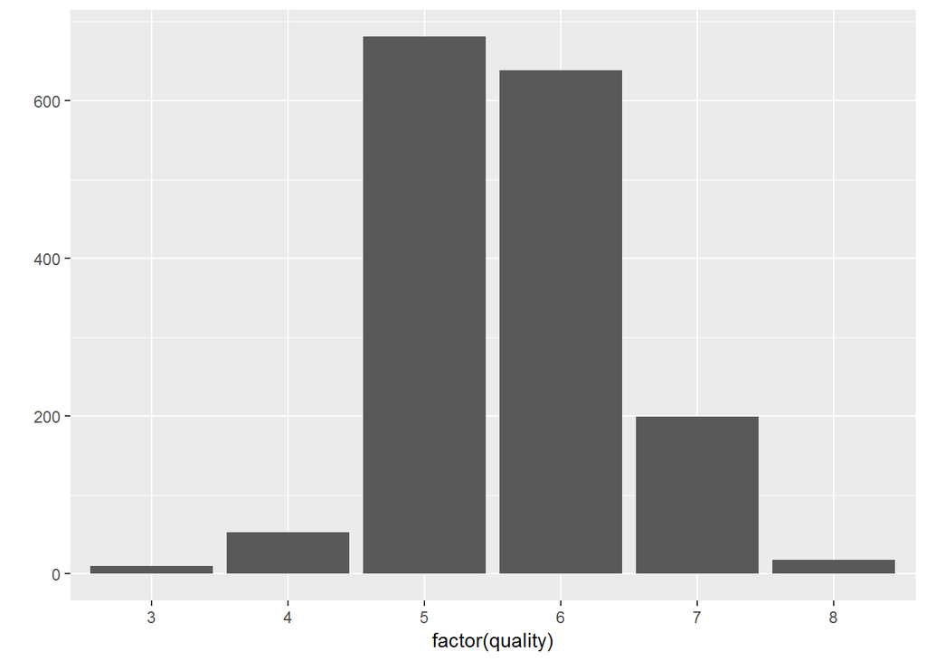

There are 6 grades for wine quality(3 to 8).  
82% of the wines have the average quality(5,6).

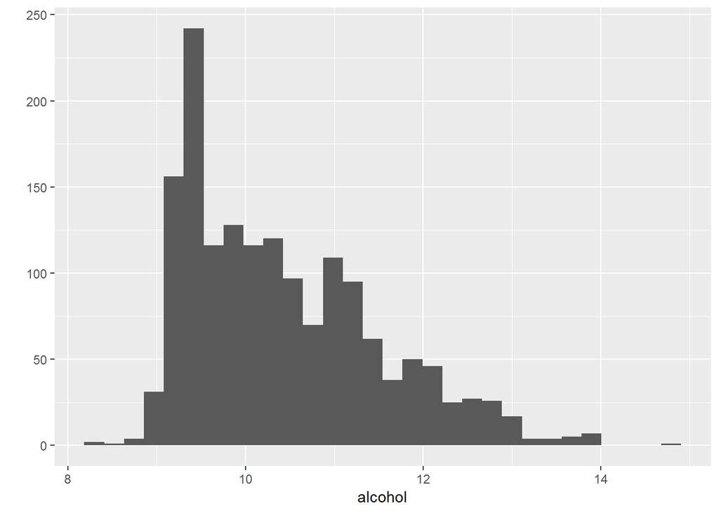

Alcohol distribution is right-skewd, mostly distributed between 8.8 to 13.2 with a peak at 9.3.

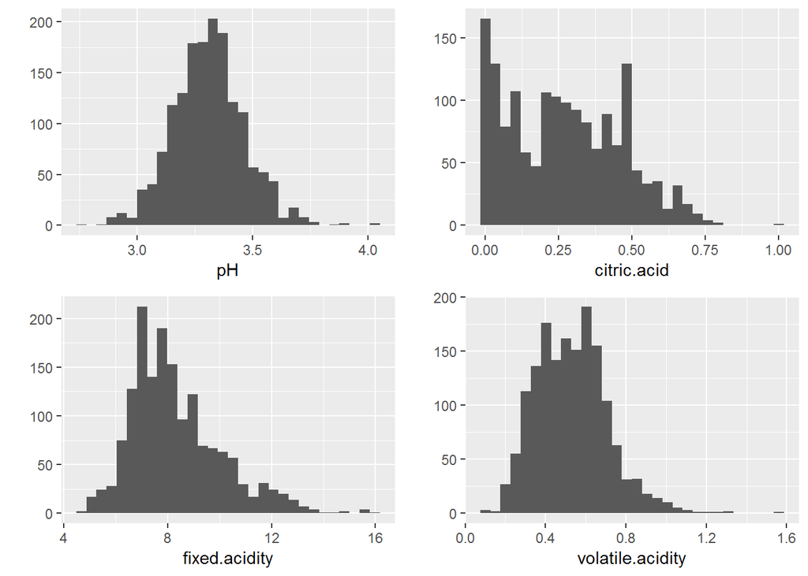

Fundamentally speaking, all wines lie on the acidic side of the pH spectrum and most range from 2.5 to about 4.5 pH (7 is neutral). ‘pH’, ‘citric.acid’, ‘fixed.acidity’ and ‘volatile.acidity’ are four features in our dataset relate to acidity attributes of wine, that’s why I invetigate them all together.  
* pH distribution is normal. Most of the wines in our data set have a pH between 3 to 3.6 with an average value of 3.3.  
* distribution of volatile cidicty is almost normal, mostly between 0.2 to 1 with an average amount of 0.5 g/dm^3.  
* Fixed acidity has right_skewed distributaion, mostly between 5 to 13 g/dm^3 with an average amount of 8.3 g/dm^3.  
8% of red wines in our dataset don’t have Citric acid at all. After researching in google, I found out that some wines dont have citric acid at all, so it’s not anomalies in our data.

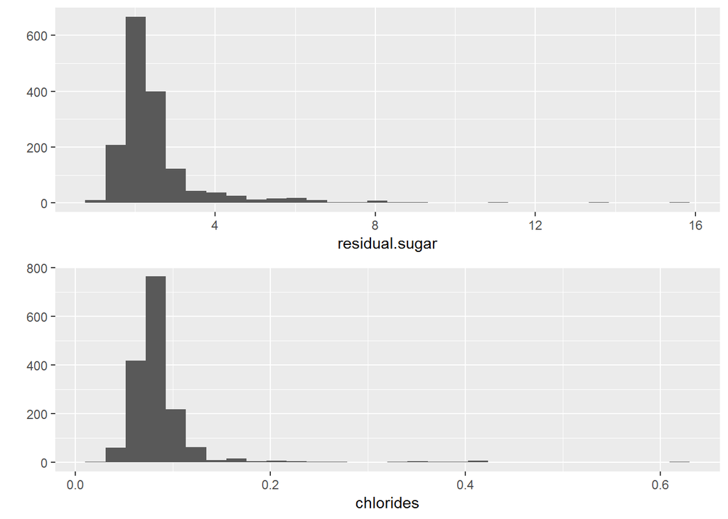

Chloride gives erd wine a salty taste, and residual sugar a sweat taste.  
* 75% of wines have less than 2.6 g/dm^3 sugar while the minimum amount is 0.9 and maximum is 15.5 g/dm^3 The distribution of residual sugar in red wine is right skewed.  
* 85% of red wines in our dataset has less than 0.1 g/dm^3 chlorides. The distribution is right skewed.

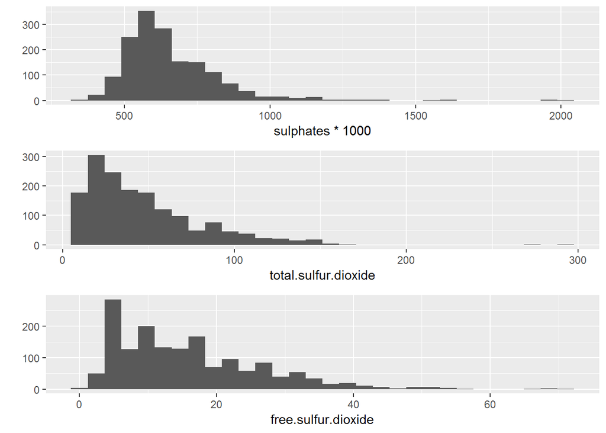

‘sulphates’, ‘total_sulfur_dioxide’ and ‘free_sulfur_dioxide’ are all related features, so I investigate them together.

Sulphates is a wine additive which can contribute to sulfur dioxide gas (S02) levels which acts as an antimicrobial and antioxidant to preserve the flavor and freshness of wines. Total sulfur dioxide includes free and bound forms of S02. The free form of SO2 prevents microbial growth and the oxidation of wine.

The unit for sulphates in our data set is g/dm^3, and mg/dm^3 for free and total sulfur_dioxide, so to make a better comparison I transformed sulphates to 1000*sulphates.

All these three variables distribution skewed to the right. Total sulfur dioxide is between 0 to 150, free sulfur dioxide is between 0 to 55, and sulphate is between 300 to 1300 mg/dm^3.

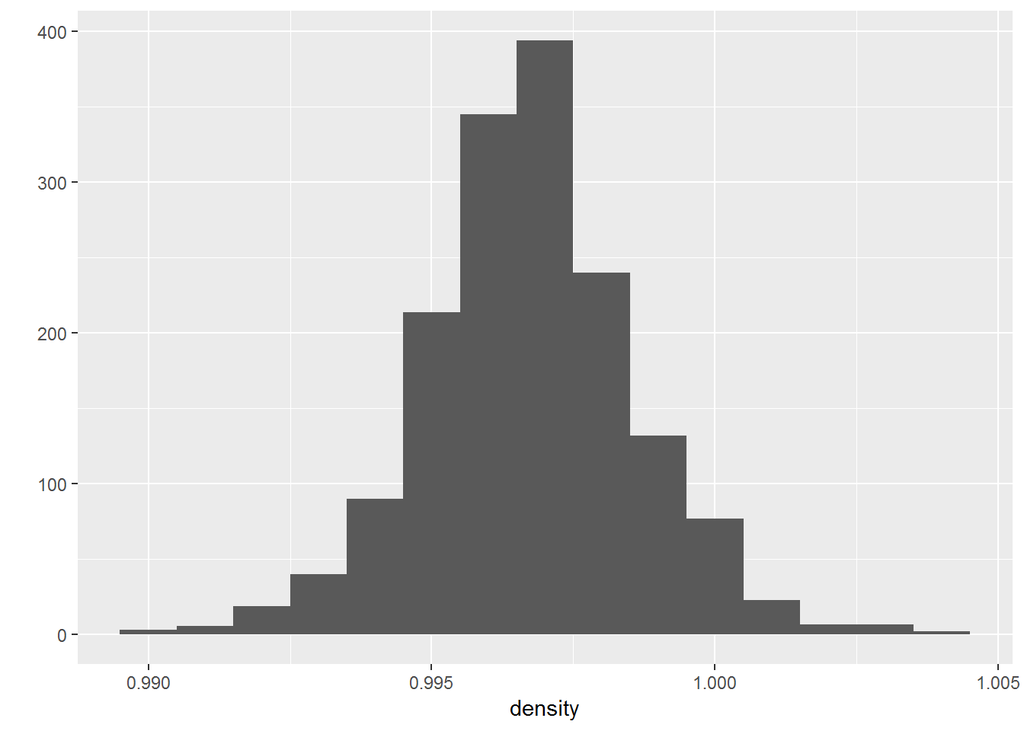

The density of red wine depends on percentage of alcohol and sugar content.  
Most of wines have a density between 0.99 to 1 g/dm^3 and the distribution is normal.

# Univariate Analysis

### What is the structure of your dataset?

There are 1599 wines in the dataset with 12 features(fixed.acidity, voatile.acidity, citric.acid, residual.sugar, chlorides, free.sulfur,dioxide, total.sulfar.dioxide, density, pH, sulphates, alcohol, quality) All variables in our dataset are numeric variables. I use ‘quality’ as a categorical variable in this report’s plots.

### What is/are the main feature(s) of interest in your dataset?

The main feature in our dataset is quality, I’d like to determine which chemical properties influence the quality of red wines. 3 is the worst and 8 is the best quality.

### What other features in the dataset do you think will help support your investigation into your feature(s) of interest?

I expect alcohol, residual.sugar and acidity(which includes four features:pH, fixed and volatile.acidity and citric acid) have the most effect on the quality.

### Did you create any new variables from existing variables in the dataset?

No

### Of the features you investigated, were there any unusual distributions? Did you perform any operations on the data to tidy, adjust, or change the form of the data? If so, why did you do this?

# Bivariate Plots Section

```
##                      fixed.acidity volatile.acidity citric.acid
## fixed.acidity                 1.00            -0.26        0.67
## volatile.acidity             -0.26             1.00       -0.55
## citric.acid                   0.67            -0.55        1.00
## residual.sugar                0.11             0.00        0.14
## chlorides                     0.09             0.06        0.20
## free.sulfur.dioxide          -0.15            -0.01       -0.06
## total.sulfur.dioxide         -0.11             0.08        0.04
## density                       0.67             0.02        0.36
## pH                           -0.68             0.23       -0.54
## sulphates                     0.18            -0.26        0.31
## alcohol                      -0.06            -0.20        0.11
## quality                       0.12            -0.39        0.23
##                      residual.sugar chlorides free.sulfur.dioxide
## fixed.acidity                  0.11      0.09               -0.15
## volatile.acidity               0.00      0.06               -0.01
## citric.acid                    0.14      0.20               -0.06
## residual.sugar                 1.00      0.06                0.19
## chlorides                      0.06      1.00                0.01
## free.sulfur.dioxide            0.19      0.01                1.00
## total.sulfur.dioxide           0.20      0.05                0.67
## density                        0.36      0.20               -0.02
## pH                            -0.09     -0.27                0.07
## sulphates                      0.01      0.37                0.05
## alcohol                        0.04     -0.22               -0.07
## quality                        0.01     -0.13               -0.05
##                      total.sulfur.dioxide density    pH sulphates alcohol
## fixed.acidity                       -0.11    0.67 -0.68      0.18   -0.06
## volatile.acidity                     0.08    0.02  0.23     -0.26   -0.20
## citric.acid                          0.04    0.36 -0.54      0.31    0.11
## residual.sugar                       0.20    0.36 -0.09      0.01    0.04
## chlorides                            0.05    0.20 -0.27      0.37   -0.22
## free.sulfur.dioxide                  0.67   -0.02  0.07      0.05   -0.07
## total.sulfur.dioxide                 1.00    0.07 -0.07      0.04   -0.21
## density                              0.07    1.00 -0.34      0.15   -0.50
## pH                                  -0.07   -0.34  1.00     -0.20    0.21
## sulphates                            0.04    0.15 -0.20      1.00    0.09
## alcohol                             -0.21   -0.50  0.21      0.09    1.00
## quality                             -0.19   -0.17 -0.06      0.25    0.48
##                      quality
## fixed.acidity           0.12
## volatile.acidity       -0.39
## citric.acid             0.23
## residual.sugar          0.01
## chlorides              -0.13
## free.sulfur.dioxide    -0.05
## total.sulfur.dioxide   -0.19
## density                -0.17
## pH                     -0.06
## sulphates               0.25
## alcohol                 0.48
## quality                 1.00
```

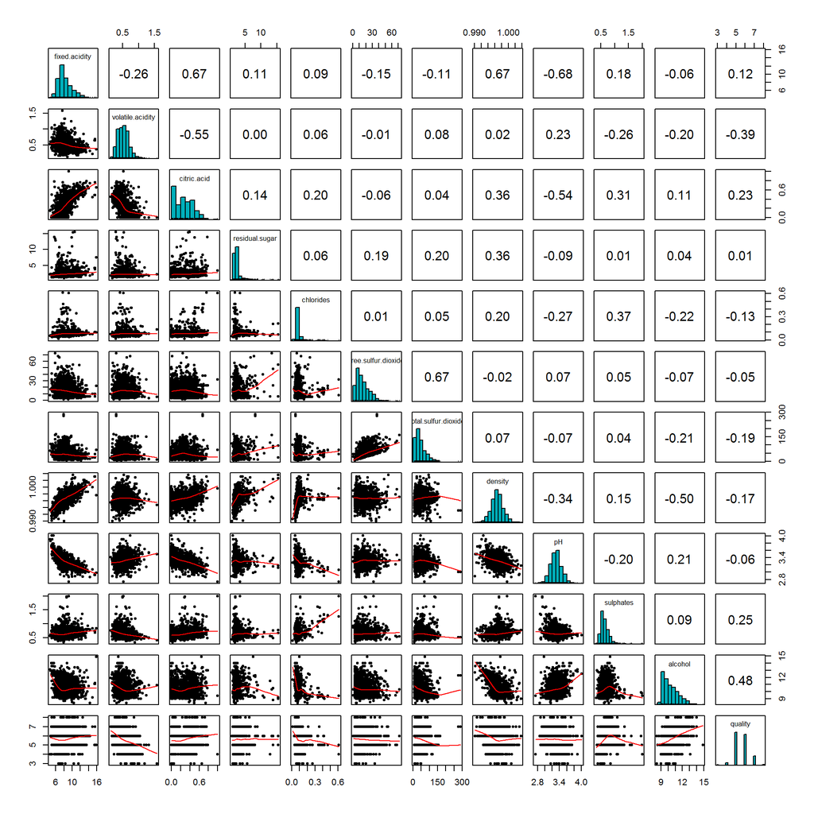

For a closer look, I’ll continue working on the features which are more effective on red wine quality.

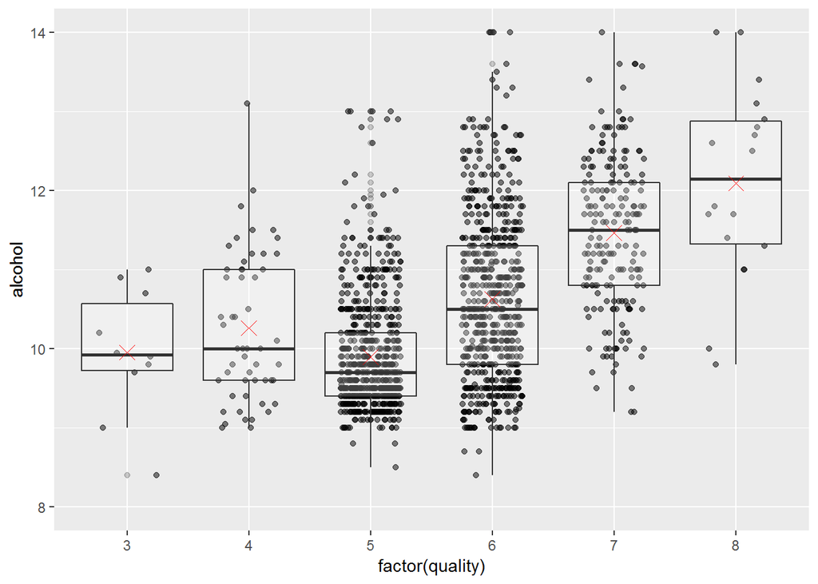

```
## df$quality: 3
##    Min. 1st Qu.  Median    Mean 3rd Qu.    Max.
##   8.400   9.725   9.925   9.955  10.575  11.000
## --------------------------------------------------------
## df$quality: 4
##    Min. 1st Qu.  Median    Mean 3rd Qu.    Max.
##    9.00    9.60   10.00   10.27   11.00   13.10
## --------------------------------------------------------
## df$quality: 5
##    Min. 1st Qu.  Median    Mean 3rd Qu.    Max.
##     8.5     9.4     9.7     9.9    10.2    14.9
## --------------------------------------------------------
## df$quality: 6
##    Min. 1st Qu.  Median    Mean 3rd Qu.    Max.
##    8.40    9.80   10.50   10.63   11.30   14.00
## --------------------------------------------------------
## df$quality: 7
##    Min. 1st Qu.  Median    Mean 3rd Qu.    Max.
##    9.20   10.80   11.50   11.47   12.10   14.00
## --------------------------------------------------------
## df$quality: 8
##    Min. 1st Qu.  Median    Mean 3rd Qu.    Max.
##    9.80   11.32   12.15   12.09   12.88   14.00
```

AS I expected, Higher quality wines have more alcohol. Althogh wines with quality 5 have the lowest average alcohol amount. There are so many outliers in wines with quality 5.

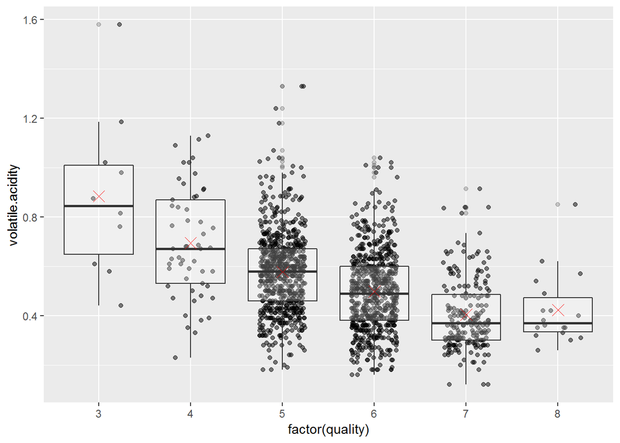

Better wines have less amount of volatile acid. Nobody likes a wine tasting vinegar.

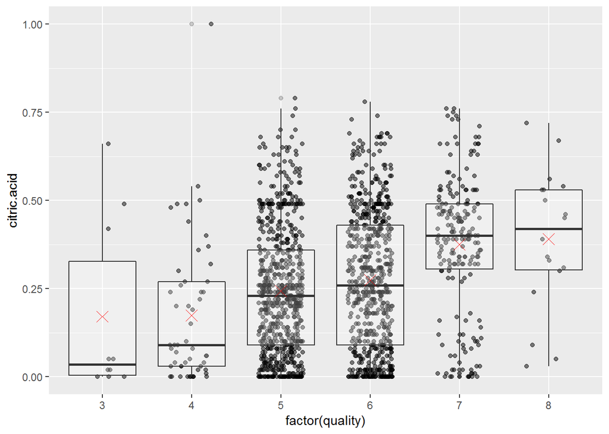

Better wines have higher level of citric.acid.

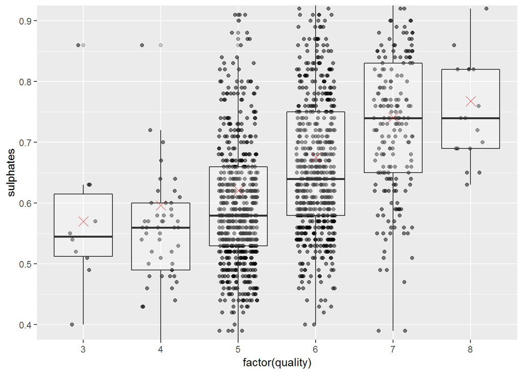

We see that best quality wines have most sulphates amount, because sulphates preserves the flavor and freshness of wine. Let’s see the relation between sulphates and citric.acid/volatile.acid.

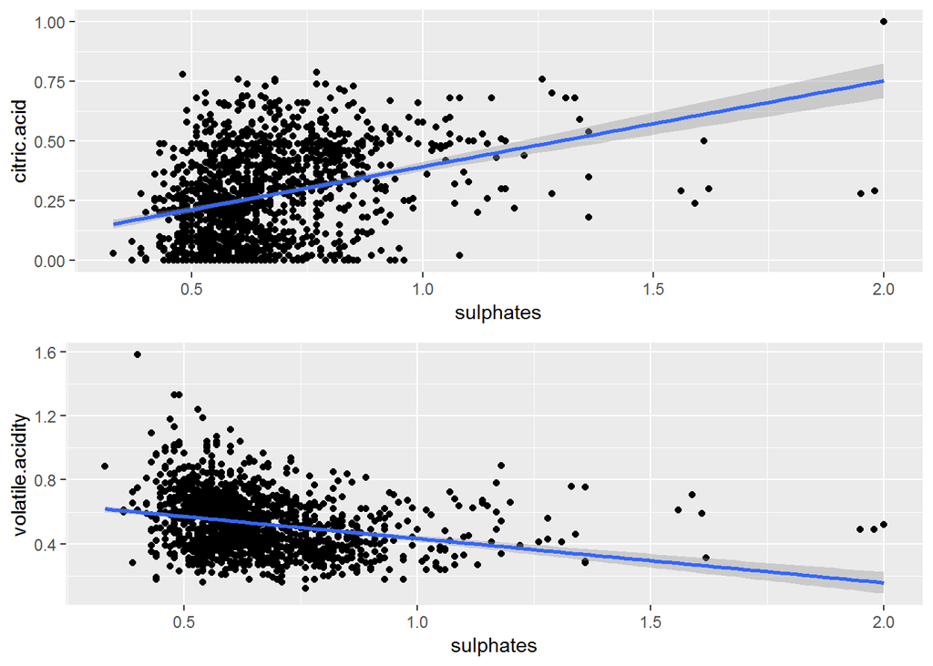

Since red wine is very perishable, sulphates as a preservative helps keeping the amount of volatile acid lower, and citric.acid higher. These two plots confirm what I concluded in the last plot.

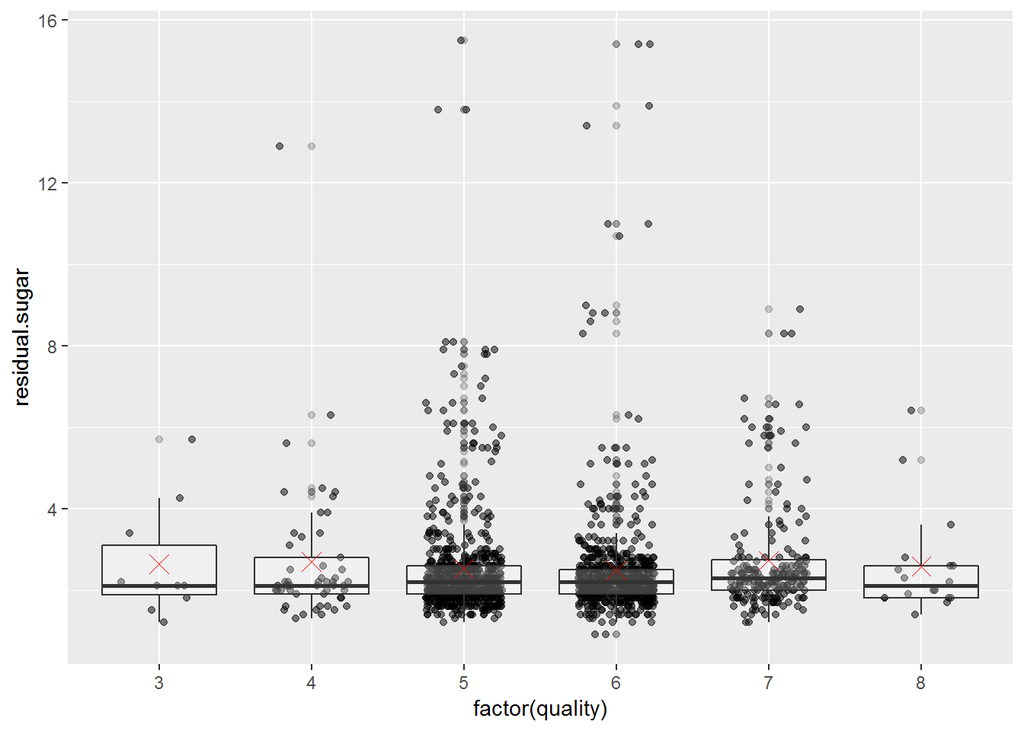

```
## df$quality: 3
##    Min. 1st Qu.  Median    Mean 3rd Qu.    Max.
##   1.200   1.875   2.100   2.635   3.100   5.700
## --------------------------------------------------------
## df$quality: 4
##    Min. 1st Qu.  Median    Mean 3rd Qu.    Max.
##   1.300   1.900   2.100   2.694   2.800  12.900
## --------------------------------------------------------
## df$quality: 5
##    Min. 1st Qu.  Median    Mean 3rd Qu.    Max.
##   1.200   1.900   2.200   2.529   2.600  15.500
## --------------------------------------------------------
## df$quality: 6
##    Min. 1st Qu.  Median    Mean 3rd Qu.    Max.
##   0.900   1.900   2.200   2.477   2.500  15.400
## --------------------------------------------------------
## df$quality: 7
##    Min. 1st Qu.  Median    Mean 3rd Qu.    Max.
##   1.200   2.000   2.300   2.721   2.750   8.900
## --------------------------------------------------------
## df$quality: 8
##    Min. 1st Qu.  Median    Mean 3rd Qu.    Max.
##   1.400   1.800   2.100   2.578   2.600   6.400
```

To my suprise, there isn’t any trend in level of sugar for wines with differnt quality level, but it confirms my first finding from correlation table.

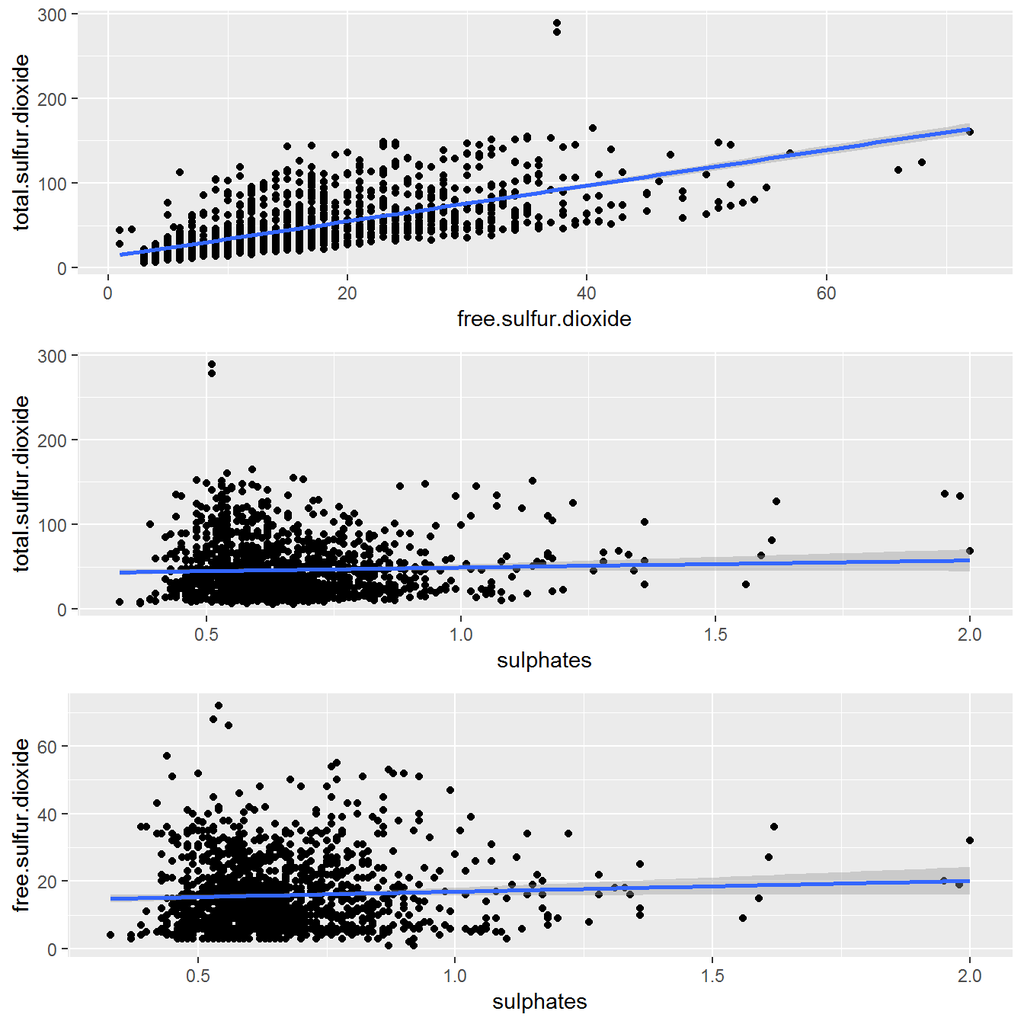

That’t my second suprise, sulphates is one of the ingredients of free and total sulfur dioxide, and free and total so2 are strongly correlated, but there isn’t any relation between sulphates amount and that two forms of sulfur.dioxide.

# Bivariate Analysis

### Talk about some of the relationships you observed in this part of the investigation. How did the feature(s) of interest vary with other features in the dataset?

Wines with better quality tend to have higher level of alcohol.

Better wines have more amount of citric acid, but lower level of volatile acid which makes, because volatile acid increases with bacterial growth and causes vinegar flavor in wine. Although weakly correlated, better quality wines tend to have more sulphates.

Because sugar gives a sweet taste, residual.sugar was one of the features I was considering to have relationsship with red wine quality, but there isn’t any relation between wine quality and the amount of sugar. However I found sulphates feature weakly correlated with red wine quality.

### Did you observe any interesting relationships between the other features (not the main feature(s) of interest)?

As fixed.acidity and citric.acid increases, pH decresses, but as volatile.acid increases, pH increases. As citric acid increases, fixed acidity increases too.  
Wine receives it acidic feature from fixed acids including citric.acid, not voaltile acid.

free.sulfur.dioxide and total.sulfur.dioxide are correlated too.

### What was the strongest relationship you found?

The stongest correlation is 0.68 between fixed.acidity and pH/density/citric.acid.  
There is the same correlation between free.sulfur.dioxide and total.sulfur.dioxide.

For ‘quality’ feature which is my main feature of interest, the quality moderatly and positively correlates with alcohol, and moderatly and negatively coralates with Volatile acid.

# Multivariate Plots Section

In this section I want to analyze relation between my main features impacting ‘quality’, to see how their interactions changes ‘quality’.

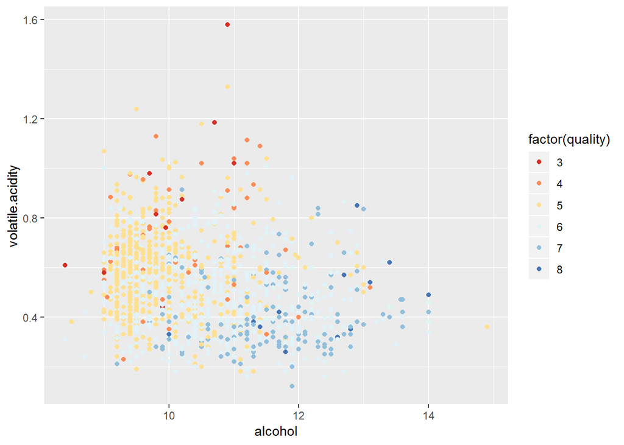

High quality red wines(blue dots) have more alcohol and less volatile acid, but there isn’t any relationship between alcohol and volatile acid.

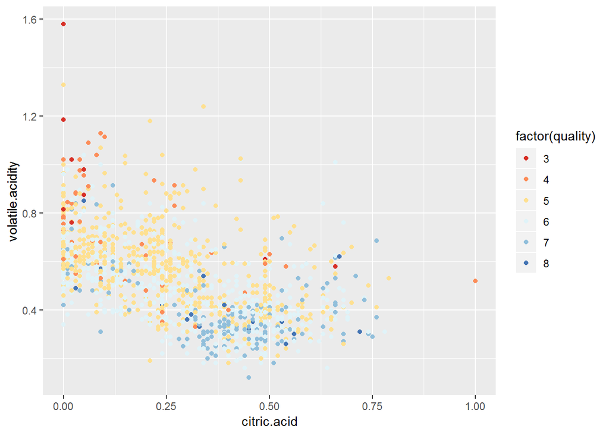

There is a moderate negative correlation between citiric acid and volatile acid, and btter wines have more citric.acid and less volatile acid.

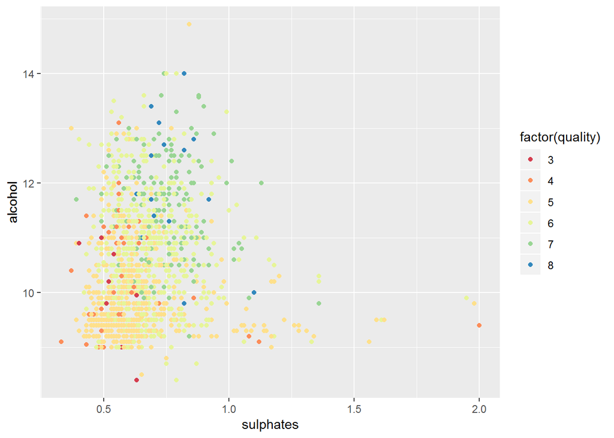

Better wines have more level of sulphates and alcohol, but doesn’t seem sulphates help keep alcohol level high.

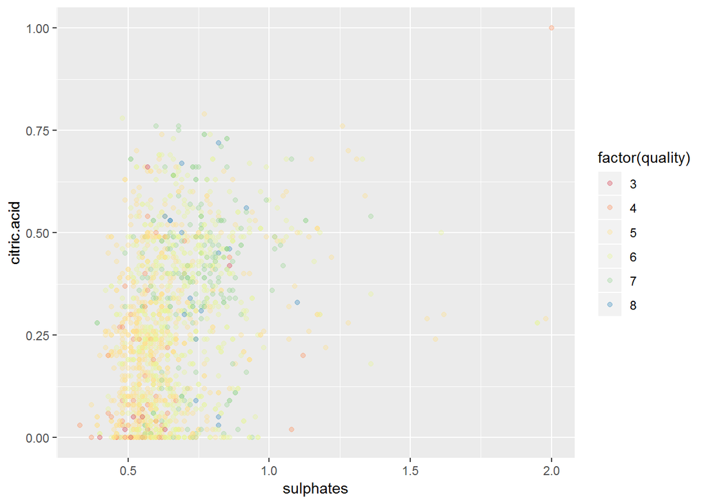

Higher quality wines have more level of citric acid and sulphates, and there isn a weak correlation between sulphates and citirc acid.

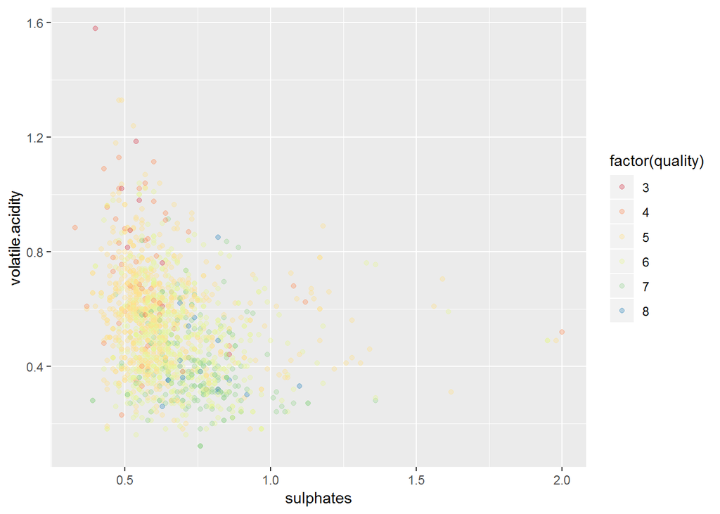

# Multivariate Analysis

### Talk about some of the relationships you observed in this part of the investigation. Were there features that strengthened each other in terms of looking at your feature(s) of interest?

Higher quality wines have definitly more level of alcohol. Higher level of citirc acid and sulphates and lower level of volatile acid are other criteria for a higher quality wine.

### Were there any interesting or surprising interactions between features?

As citic acid increases, volatile acid decreases. The correlation between them is -0.55.

### OPTIONAL: Did you create any models with your dataset? Discuss the strengths and limitations of your model.

No

# Final Plots and Summary

### Plot One

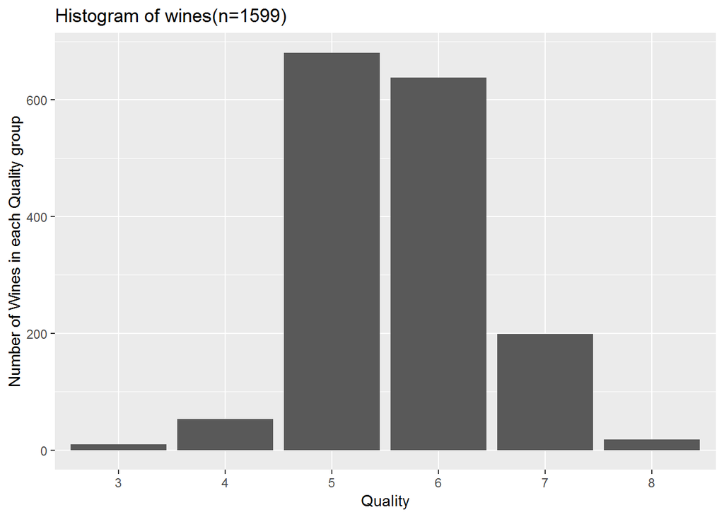

### Description One

In this research, Quality is the main feature I invistigated. The distribution in quality shows that wine in our dataset are categorized as followed:  
* 82% in the middle level quality(5,6) * 14% in the high level quality(7,8) * 4% in the low level quality(3,4)

### Plot Two

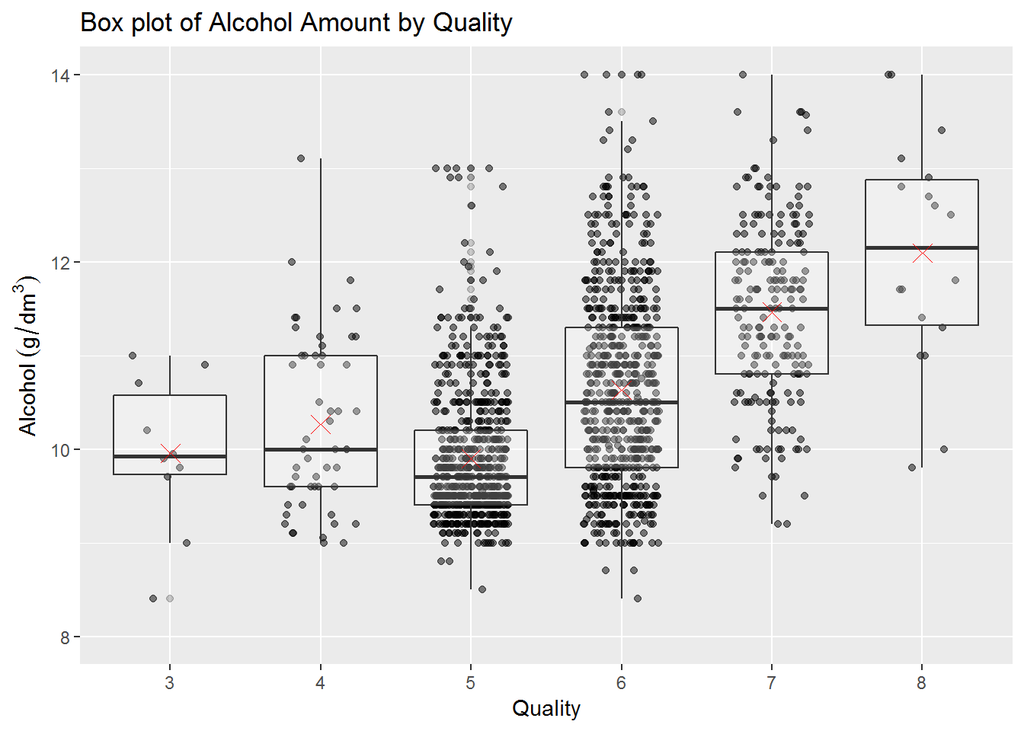

### Description Two

As Quality of wine increase, alcohol increases too, although the lowest alcohol level is in wines with qulity 5. There are so many outliers in this category.

### Plot Three

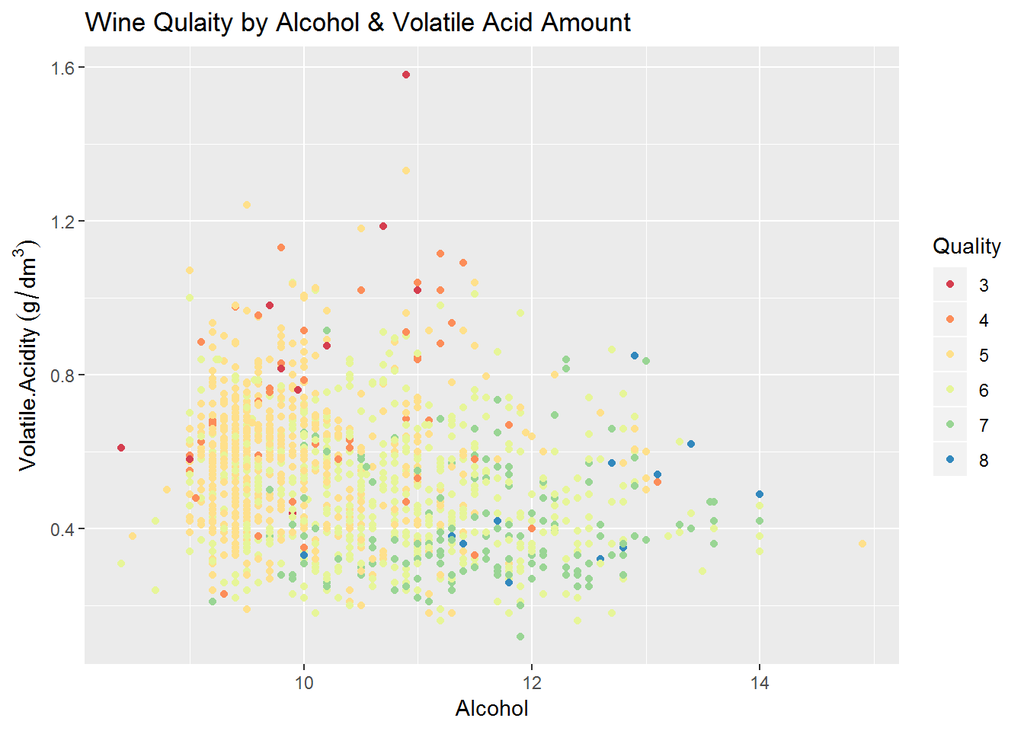

### Description Three

The plot shows that there isn’t any relationship between alcohol and volatile acid amount in wine, but the quality of wine goes up when alcohol amount increases and volatile acid decreases.

# Reflection

The Red_wine data set contains information on almost 1600 red wines across 13 variables. I started by understanding the individual variables in the data set, and then I explored interesting questions as I continued to make observations on plots. Eventually, I explored the ‘quality’ of red wines across many variables and found the most important variables that impact the quality of red wine.

There was a moderate correlation between ‘alcohol’ and ‘volatile.acidity’ amount of red wine and its ‘quality’. ‘citric.acid’ and ‘sulphates’ weekly impact the quality of red wine too.  
I was expecting sugar level of wine effects the quality too, which it doesn’t. The correlation between ‘residual.sugar’ and ‘quality’ is 0.01.

I think ‘age’ and ‘tannin’ are two other important features in red wine quality, which our dataset doessn’t include. Also we don’t have any information on other acids in red wine: ‘tartaric’ and ‘malic’. They should have impact on quality.